# tinytest2JUnit Progress

May 09, 2023

## Outline

- Motivation
- Sources
- Package Developement
- Testing Tinytests2JUnit
- 3 Ways to Run Tests
- Jenkins Demo
- Issues

## Motivation

- Tinytest is a lightweight, no-dependency, full-featured package for unit testing
- Testing language structure similar to `testthat` (`expect_*`)
- Applicability for Jenkins?
- Jenkins uses JUnit XML format to report about the test suite execution
- Tinytest has no build in reporter for JUnit format:

  **-> Tinytest2JUnit**

## Sources

- git: https://scm.openanalytics.eu/git/tinytest2JUnit
- Redmine: https://projects.openanalytics.eu/projects/tinytest2junit/
  - as subproject of “Team DST”

## Package Developement

- Convert tinytest test’s results output to JUnit xml:
  - Source code written by Lennart

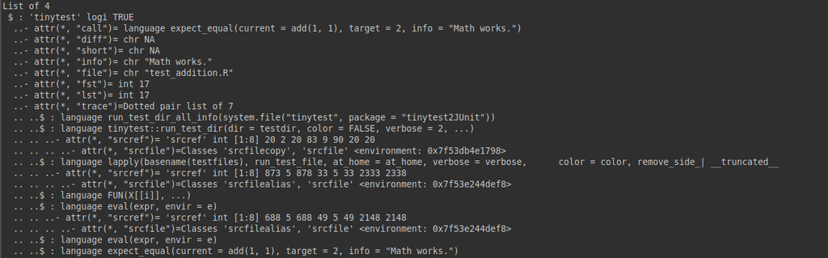

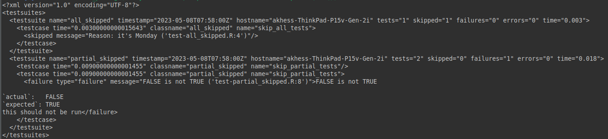

tinytest object

## Testing Tinytests2JUnit

- Different test scenarios
- To test the package we need to use the package itself
- master branch - test package functionality:
  - `test_writeJUnit.R` loops over example_tests folder
- separate branches for special test cases:
  - see Jenkins output - tests allowed to fail

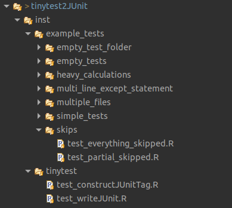

## 3 Ways to Run Tests in Tinytest

`tinytest::test_package("mypkg", testdir = "inst/tinytest") tinytest::test_all(pkgdir = "mypkg") tinytest::run_test_dir(system.file("mypkg", package="tinytest2JUnit"))`

- `test_package`: test a package during R CMD check -> causes Jenkins pipeline to fail on fail of any test
- `test_all`: runs tests interactively -> causes pipeline to exit on fail of any test
- **`run_test_dir` is the only function that stores test results without exiting Jenkins pipeline**

## Jenkins Demo

- Updated Jenkinsfile: pipeline is working

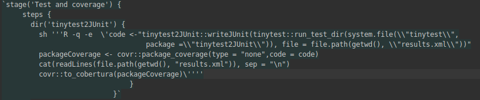

https://ci.openanalytics.eu/job/git/job/tinytest2JUnit/

## Issues

### Pipeline fails with empty test folder

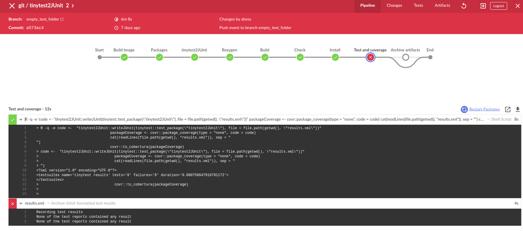

## Issues

### Pipeline fails with empty test folder

Can be easily fixed by running:

`tinytest::setup_tinytest("mypkg")`

- sets up testing framework:
  - folder in `"inst/tinytest/"` that contains example test file
  - add `"tests/tinytest.R"`, which is needed to run tests during R CMD check
  - add tinytest to Suggests in DESCRIPTION file

## Issues

### Test Duration is not reported

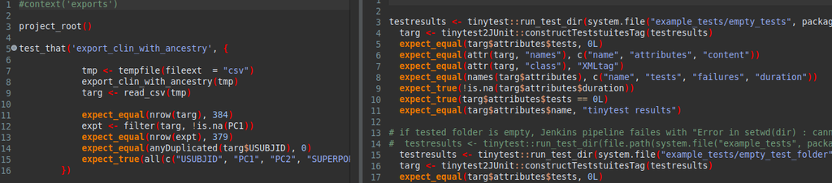

testthat vs. tinytest

## Issues

### Skipped tests are not reported

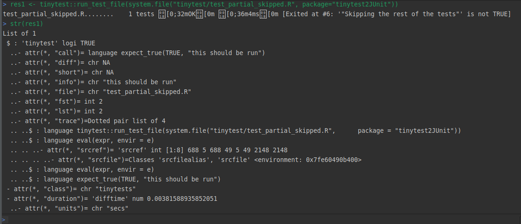